# Q1

Q1:

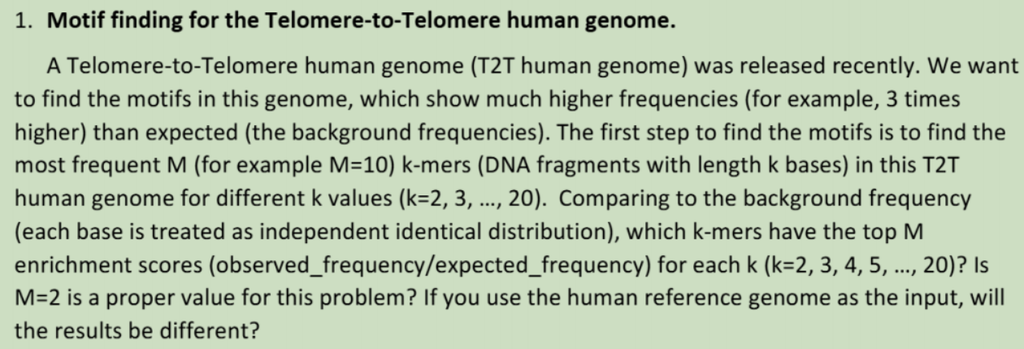

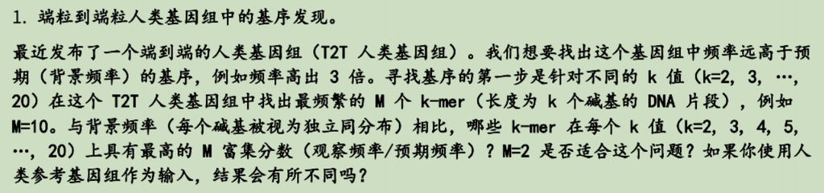

一，数据准备

1，T2T人类基因组（chm13v2.0.fa）

2，人类参考基因组（GRCh38.p14）

在/lustre/share/class/BIO8402/exam/chr/中访问

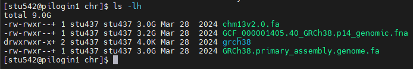

3，软件准备

Jellyfish https://github.com/gmarcais/Jellyfish

```python
!sudo apt update
!sudo apt install jellyfish
```

参考文档：https://github.com/gmarcais/Jellyfish/tree/master/doc

```python
!jellyfish count  -V
```

```
2.3.1
```

```python
#!/bin/bash
genomefa_dir="/data1/project/omics_final"
Q1_dir="/data1/project/omics_final/Q1"
genomes=(T2T GRCh38_p14)
mer_lens=($(seq 2 20))

mkdir -p ${Q1_dir}
for genome in ${genomes[@]};do

    for i in ${mer_lens[@]};do
        # 1，统计所有 k-mer
        jellyfish count -m ${i} \
            -s 3G \
            -t 20 \
            -o ${Q1_dir}/${genome}_${i}.jf \
             ${genomefa_dir}/${genome}.fa
    done
done
```

如果要输出文件中所有k-mer的计数count，可以使用dump命令对于结果文件，可以进行处理构建字典文件

```python
#!/bin/bash
Q1_dir="/data1/project/omics_final/Q1"

for jf in ${Q1_dir}/*.jf;do

    prefix=$(basename ${jf} .jf)

    jellyfish dump ${jf} > ${Q1_dir}/${prefix}.txt # 输出文件中所有k-mer的计数，参考https://github.com/gmarcais/Jellyfish/tree/master/doc#dump
    jellyfish histo ${jf} > ${Q1_dir}/${prefix}.histo # 计算k-mer出现的直方图，参考https://github.com/gmarcais/Jellyfish/tree/master/doc#histo
    jellyfish stats ${jf} > ${Q1_dir}/${prefix}.stats # 一些额外的统计信息，参考

done
```

```python
#!/bin/bash
Q1_dir="/data1/project/omics_final/Q1"

for jf in ${Q1_dir}/*.jf;do

    prefix=$(basename ${jf} .jf)

    jellyfish dump -c ${jf} > ${Q1_dir}/${prefix}.txt  # 输出格式需求

done
```

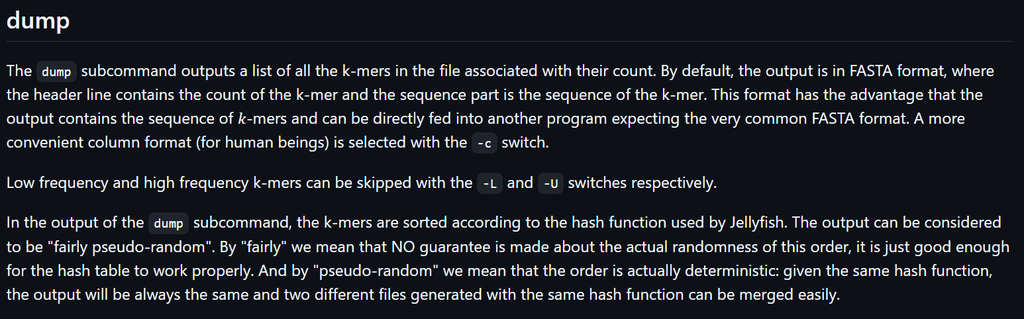

```python
!head -n 10 /data1/project/omics_final/Q1/GRCh38_p14_10.txt
```

```
18645.79s - pydevd: Sending message related to process being replaced timed-out after 5 seconds
```

```
AAAAAAAAAA 3180326
AAAAAAAAAC 126400
AAAAAAAAAG 333877
AAAAAAAAAT 245486
AAAAAAAACA 87211
AAAAAAAACC 44353
AAAAAAAACG 5250
AAAAAAAACT 45564
AAAAAAAAGA 224131
AAAAAAAAGC 48343
```

```python
import pandas as pd
mer_10 = pd.read_csv("/data1/project/omics_final/Q1/GRCh38_p14_10.txt", sep=" ", header=None, names=["kmer", "count"])
mer_10["kmer"].head(20)
```

```
0     AAAAAAAAAA
1     AAAAAAAAAC
2     AAAAAAAAAG
3     AAAAAAAAAT
4     AAAAAAAACA
5     AAAAAAAACC
6     AAAAAAAACG
7     AAAAAAAACT
8     AAAAAAAAGA
9     AAAAAAAAGC
10    AAAAAAAAGG
11    AAAAAAAAGT
12    AAAAAAAATA
13    AAAAAAAATC
14    AAAAAAAATG
15    AAAAAAAATT
16    AAAAAAACAA
17    AAAAAAACAC
18    AAAAAAACAG
19    AAAAAAACAT
Name: kmer, dtype: object
```

二，数据处理

1，计算富集分数

```python
import mermaid as md
```

```python
%%mermaidjs
graph LR
A[基因组] --> B[统计单碱基频率]
A --> C[计算所有k-mer频数]
B --> D[计算每个k-mer预期频率]
C --> E[计算观测频率]
D & E --> F[富集分数=观测/预期]
F --> G[取Top M富集分数]
```

[figure not shown]

enrichment scores = observed_frequency/expected_frequency

observed_frequency = k-mer count / total count of k-mers

观测频率 = 某个k-mer在基因组中出现的次数 / 基因组中所有k-mer的总数(k固定)

expected_frequency = 单碱基频率累积（独立同分布）

此处使用基因组实际碱基频率，即jellyfish计算1-mer，统计实际单碱基ACGT的频率，而非理论的1/4

```python
!cat  /data1/project/omics_final/Q1/GRCh38_p14_1.txt

!echo -e "\n"

!cat /data1/project/omics_final/Q1/T2T_1.txt
```

```
A 923117203
C 642552917
G 645231996
T 925917038


A 923878813
C 633696734
G 636722544
T 922993979
```

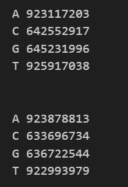

前者是GRCH38_p14的单碱基频数

后者是T2T的单碱基频数

```python
# 计算预期频率，在GRCH38_p14中
A_freq = 923117203/(923117203+642552917+645231996+925917038) = 0.2942844830001953
C_freq = 642552917/(923117203+642552917+645231996+925917038) = 0.20484219378112098
G_ferq = 645231996/(923117203+642552917+645231996+925917038) = 0.20569626883883788
T_freq = 925917038/(923117203+642552917+645231996+925917038) = 0.2951770543798458
expected_freq = A_freq * C_freq * G_ferq * T_freq

# {A: 0.2942844830001953, C: 0.20484219378112098, G: 0.20569626883883788, T: 0.2951770543798458}

# 计算预期频率，在T2T中
A_freq = 923878813/(923878813+633696734+636722544+922993979) = 0.2963722334173198
C_freq = 633696734/(923878813+633696734+636722544+922993979) = 0.20328436340583256
G_ferq = 636722544/(923878813+633696734+636722544+922993979) = 0.20425501675882426
T_freq = 922993979/(923878813+633696734+636722544+922993979) = 0.2960883864180234
expected_freq = A_freq * C_freq * G_ferq * T_freq

# {A: 0.2963722334173198, C: 0.20328436340583256, G: 0.20425501675882426, T: 0.2960883864180234}
```

```python
import pandas as pd
import argparse

def calculate_enrichment_score(kmer_file,total_obs_count,exp_freq_dict_type,top_m=10):
    """
    Args:
        kmer_file (str): 包含k-mer及其计数的文件路径
        total_obs_count (int): 总的观测计数，用于计算top k-mer文件中每一行的观测频率，
        通过shell命令计算：cut -d " " -f 2 该k-mer文件 | awk '{sum+=$1} END {print sum}'
        exp_freq_dict_type (str):预期频率字典类型，取值为"grch38_p14"或"t2t"，分别对应GRCh38_p14和T2T基因组的预期频率
        也可以自己设置1个参数，通过exp_freq_dict (dict): 预期频率字典
        top_m (int): 在计算富集分数之后，取前top_m个k-mer的富集分数,默认是10

    Fun:
        计算富集分数，公式为：富集分数 = 观测频率 / 预期频率
        其中观测频率 = k-mer计数 / 总观测计数
        预期频率是一个字典，包含每个碱基的预期频率
        最终计算每个k-mer的富集分数，但是只返回top_m个
    """
    top_kmer = pd.read_csv(kmer_file,sep=" ",header=None,names=["kmer","count"])

    # 计算观测频率
    top_kmer["obs_freq"] = top_kmer["count"] / total_obs_count

    # 计算预期频率
    # 这里需要拆分k-mer，计算每个碱基的预期频率，注意第一列是个可迭代器，每个元素k-mer又是一个迭代器，用for i in top_kmer["kmer"]不行
    grch38_p14_freq = {"A": 0.2942844830001953, "C": 0.20484219378112098, "G": 0.20569626883883788, "T": 0.2951770543798458}
    t2t_freq = {"A": 0.2963722334173198, "C": 0.20328436340583256, "G": 0.20425501675882426, "T": 0.2960883864180234}
    if exp_freq_dict_type == "grch38_p14":
        exp_freq_dict = grch38_p14_freq
    elif exp_freq_dict_type == "t2t":
        exp_freq_dict = t2t_freq
    else:
        raise ValueError("exp_freq_dict_type must be 'grch38_p14' or 't2t'")

    def calc_exp_freq(kmer,exp_freq_dict):
        freq = 1.0
        for base in kmer:
            freq *= exp_freq_dict.get(base,0) # 如果碱基不在预期频率字典中，默认为0
        return freq

    top_kmer["exp_freq"] = top_kmer["kmer"].apply(lambda x: calc_exp_freq(x, exp_freq_dict))

    # 计算富集分数
    top_kmer["enrichment_score"] = top_kmer["obs_freq"] / top_kmer["exp_freq"]

    # 取前top_m个k-mer
    top_kmer = top_kmer.sort_values(by="enrichment_score", ascending=False).head(top_m)

    # 输出为tsv格式文件
    top_kmer.to_csv(kmer_file.replace(".txt", f"_top{top_m}.tsv"), sep="\t", header=True, index=False)

# 使用parse_args()函数来解析命令行参数
if __name__ == "__main__":

    parser = argparse.ArgumentParser(description="为每一个k-mer文件中的k-mer计算富集分数，并输出前top_m个k-mer")
    parser.add_argument("kmer_file", type=str, help="kmer文件路径")
    parser.add_argument("total_obs_count", type=int, help="该k-mer文件的总观测计数")
    parser.add_argument("exp_freq_dict_type", type=str, help="预期频率字典类型，取值为'grch38_p14'或't2t'，分别对应GRCh38_p14和T2T基因组的预期频率")
    parser.add_argument("--top_m", type=int, default=10, help="在计算富集分数之后，取前top_m个k-mer的富集分数,默认是10")

    args = parser.parse_args()

    calculate_enrichment_score(args.kmer_file, args.total_obs_count, args.exp_freq_dict_type, args.top_m)
```

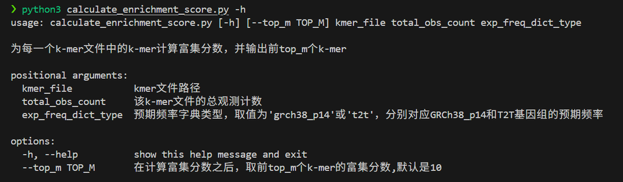

（1）2-mer的top 10：

```python
# grch38_p14的观测频率
!cat /data1/project/omics_final/Q1/GRCh38_p14_2_top10.txt

# 总频数
!cut -d " " -f 2 /data1/project/omics_final/Q1/GRCh38_p14_2.txt | awk '{sum+=$1} END {print sum}'
```

```
TT 307338594
AA 304674050
AT 240192446
TG 228776442
CA 227637894
AG 219986719
CT 219728966
TA 202748537
GA 188056148
TC 187053091
3136817227
```

```python
# 输出观测频率
!sort -k2 -nr /data1/project/omics_final/Q1/GRCh38_p14_2.txt | head -n 10 | awk '{if(NR==1){while((getline line<"/data1/project/omics_final/Q1/GRCh38_p14_2.txt")>0){split(line,a," ");sum+=a[2]}} print $1, $2, $2/sum}'

# 计算预期频率，拆分k-mer，用python字典
```

```
TT 307338594 0.0979778
AA 304674050 0.0971284
AT 240192446 0.076572
TG 228776442 0.0729327
CA 227637894 0.0725697
AG 219986719 0.0701306
CT 219728966 0.0700484
TA 202748537 0.0646351
GA 188056148 0.0599513
TC 187053091 0.0596315
```

```python
# 2-mer的观测频数总数
# GRCh38_p14的总观测频数
!cut -d " " -f 2 /data1/project/omics_final/Q1/GRCh38_p14_2.txt | awk '{sum+=$1} END {print sum}'

# T2T的观测频率
!cut -d " " -f 2 /data1/project/omics_final/Q1/T2T_2.txt | awk '{sum+=$1} END {print sum}'
```

```
3136817227
3117292045
```

```python
# 计算GRCH38_p14的2-mer
python3 /data1/project/omics_final/calculate_enrichment_score.py \
    /data1/project/omics_final/Q1/GRCh38_p14_2.txt \
    3136817227 \
    grch38_p14 \
    --top_m 10
# 计算T2T的2-mer
python3 /data1/project/omics_final/calculate_enrichment_score.py \
    /data1/project/omics_final/Q1/T2T_2.txt \
    3117292045 \
    t2t \
    --top_m 10
```

```python
!cat /data1/project/omics_final/Q1/*_2_top10.tsv
```

```
kmer	count	obs_freq	exp_freq	enrichment_score
CC	163098580	0.05199492612962496	0.041960324353062316	1.2391450002180526
GG	164381523	0.05240392126933445	0.04231095501421946	1.2385426245217825
CA	227637894	0.07256970283146179	0.060281879093503	1.2038394277474196
TG	228776442	0.07293266564300209	0.06071681873277303	1.2011937905375687
AG	219986719	0.07013055051677067	0.060533220130306584	1.1585465033217204
CT	219728966	0.07004838028454248	0.06046471537301686	1.1585001244511348
TT	307338594	0.09797784561835422	0.08712949343236245	1.1245083812453611
AA	304674050	0.09712840371365379	0.08660335693469222	1.121531625926447
GC	134137422	0.042762268979339546	0.042135274961538786	1.0148805013939766
GA	188056148	0.059951260909088346	0.060533220130306584	0.990386118234492
kmer	count	obs_freq	exp_freq	enrichment_score
GG	162621394	0.052167519646045865	0.04172011187114758	1.2504165810284753
CC	160770721	0.05157383994799884	0.0413245324053146	1.2480199277794155
TG	227582757	0.07300655624006508	0.0604775383299066	1.2071681198697664
CA	225897602	0.0724659732675127	0.06024784080140466	1.2027978480819377
CT	213131922	0.06837085487125093	0.06019013914484804	1.135914550832254
AG	212621903	0.06820724524063641	0.060535515503504826	1.1267310548745126
AA	305696654	0.09806481060711782	0.08783650074077028	1.1164471464606052
TT	304202365	0.0975854557765697	0.08766833257162873	1.113120928778225
TC	188993326	0.06062740457800129	0.06019013914484804	1.007264735376354
GA	190069030	0.06097248100474333	0.060535515503504826	1.007218332867971
```

2-mer还好，看top2和其他也看不出差别，还有就是2-mer区分度不大，富集分数很低

(2) 3-mer的top10

```python
# 3-mer的观测频数总数
# GRCh38_p14的总观测频数
!cut -d " " -f 2 /data1/project/omics_final/Q1/GRCh38_p14_3.txt | awk '{sum+=$1} END {print sum}'
# T2T的观测频率
!cut -d " " -f 2 /data1/project/omics_final/Q1/T2T_3.txt | awk '{sum+=$1} END {print sum}'
```

```
3136815317
3117292020
```

```python
# 计算GRCH38_p14的3-mer
python3 /data1/project/omics_final/calculate_enrichment_score.py \
    /data1/project/omics_final/Q1/GRCh38_p14_3.txt \
    3136815317 \
    grch38_p14 \
    --top_m 10
# 计算T2T的3-mer
python3 /data1/project/omics_final/calculate_enrichment_score.py \
    /data1/project/omics_final/Q1/T2T_3.txt \
    3117292020 \
    t2t \
    --top_m 10
```

```python
!cat /data1/project/omics_final/Q1/*_3_top10.tsv
```

```
kmer	count	obs_freq	exp_freq	enrichment_score
CAG	64233715	0.02047736589778964	0.012399757608127514	1.6514327573925796
CTG	63478513	0.020236611526339342	0.01243736634863189	1.627081727681469
CCC	41212131	0.013138207651770402	0.008595244892248681	1.5285437258010683
GGG	41338611	0.013178528801477412	0.008703205577432862	1.514215501889203
TTT	120704898	0.03848007797776257	0.02571862722097287	1.4961948648014567
AAA	119294799	0.03803054593411372	0.025486024121607276	1.4922118001870324
TGG	58392236	0.018615133534812436	0.012489223069095468	1.49049572033632
CCA	57294743	0.018265258617391533	0.012348272358761446	1.4791752308922648
CCT	55770083	0.017779205137692843	0.012385724943359844	1.435459387237928
AGG	55618189	0.017730782140273512	0.012451457521604096	1.423992501240071
kmer	count	obs_freq	exp_freq	enrichment_score
CTG	61202846	0.01963333739904162	0.0122941378797469	1.5969673995103926
CAG	61178482	0.019625521641055625	0.012305923732573885	1.5948028012807118
TGG	60260079	0.019330905995775142	0.01235284060510751	1.5648956069086184
CCA	58685458	0.01882578135878332	0.012247443963889493	1.5371192074272373
CCC	39594072	0.01270143180233721	0.008400631263058077	1.5119615901000176
GGG	39592191	0.012700828393998198	0.008521542149421272	1.4904377835953972
TTT	116953339	0.03751760767026247	0.025957575131092193	1.4453433142652674
AAA	117178363	0.037589793400234606	0.02603229990010415	1.4439674383162826
CCT	53449511	0.017146135381952442	0.012235714119368917	1.4013187309443929
AGG	53575993	0.017186709700684377	0.012364682733672444	1.3899838815823573
```

我们可以看到，富集分数max相比2-mer有所上升，如果只是看top2的话，其实差距不大，就差1个字符，如果是看密码子表的话，其实这里就不应该只看top2，很好理解，因为其他的密码子也很重要，这里其实就能够举出只看top2不行的反例了

（3）4-mer的top10

```python
# 4-mer的观测频数总数
# GRCh38_p14的总观测频数
!cut -d " " -f 2 /data1/project/omics_final/Q1/GRCh38_p14_4.txt | awk '{sum+=$1} END {print sum}'
# T2T的观测频率
!cut -d " " -f 2 /data1/project/omics_final/Q1/T2T_4.txt | awk '{sum+=$1} END {print sum}'
```

```
3136813411
3117291995
```

```python
#计算GRCH38_p14的4-mer
python3 /data1/project/omics_final/calculate_enrichment_score.py \
    /data1/project/omics_final/Q1/GRCh38_p14_4.txt \
    3136813411 \
    grch38_p14 \
    --top_m 10
#计算T2T的4-mer
python3 /data1/project/omics_final/calculate_enrichment_score.py \
    /data1/project/omics_final/Q1/T2T_4.txt \
    3117291995 \
    t2t \
    --top_m 10
```

```python
!cat /data1/project/omics_final/Q1/*_4_top10.tsv
```

```
kmer	count	obs_freq	exp_freq	enrichment_score
CAGG	17411609	0.005550731496792877	0.0025505838744978226	2.1762591508133586
CCAG	17290487	0.005512118425459001	0.002539993550802985	2.1701308744332906
CCTG	17326413	0.005523571449688628	0.0025476974077132467	2.1680641637291047
CTGG	17347066	0.005530155519983525	0.002558319852095301	2.161635698309673
CCCA	16289497	0.005193007956060413	0.0025294471993754725	2.0530208961636283
AAAA	47778162	0.015231432584563125	0.007500141432357703	2.030819381465325
TTTT	48241758	0.015379224607631595	0.007591548625780092	2.0258349601299246
TGGG	16285790	0.005191826183505182	0.0025689865860088774	2.0209627453022603
GGAG	15544777	0.0049555950460707845	0.0025612183537992456	1.9348584780832068
CTCC	15365938	0.004898582091658878	0.002537119068967381	1.9307655488367061
kmer	count	obs_freq	exp_freq	enrichment_score
CTGG	16512928	0.005297202837105415	0.0025111393386629995	2.109481841786523
CAGG	16490152	0.005289896495563932	0.0025135466582296923	2.1045547247925933
CCAG	16404157	0.005262310051901314	0.0025016018720970096	2.1035761567807327
CCTG	16362111	0.005248822062945695	0.002499205992507881	2.100195853675372
CCCA	15509585	0.004975339180569769	0.0024897138495478823	1.9983578359710943
TGGG	15477647	0.0049650937495831216	0.0025231296648153194	1.9678313876693063
TTTT	46349180	0.014868411452742335	0.007685736535889699	1.9345460754882837
AAAA	46270993	0.014843329747170508	0.007715250862383337	1.9238946356937017
CTCC	14903024	0.004780759718340084	0.0024873293555716675	1.9220453084072227
GGAG	14911314	0.004783419077814044	0.00252554847898381	1.894011981008862
```

可以看到富集分数max已经能够突破2了，所以k-mer适当越长，至少能够逐渐逼近有生物学意义的片段

（5）5-mer的top10

```python
# 5-mer的观测频数总数
# GRCh38_p14的总观测频数
!cut -d " " -f 2 /data1/project/omics_final/Q1/GRCh38_p14_5.txt | awk '{sum+=$1} END {print sum}'
# T2T的观测频率
!cut -d " " -f 2 /data1/project/omics_final/Q1/T2T_5.txt | awk '{sum+=$1} END {print sum}'
```

```
3136811515
3117291970
```

```python
# 计算GRCH38_p14的5-mer
python3 /data1/project/omics_final/calculate_enrichment_score.py \
    /data1/project/omics_final/Q1/GRCh38_p14_5.txt \
    3136811515 \
    grch38_p14 \
    --top_m 10
# 计算T2T的5-mer
python3 /data1/project/omics_final/calculate_enrichment_score.py \
    /data1/project/omics_final/Q1/T2T_5.txt \
    3117291970 \
    t2t \
    --top_m 10
```

```python
!cat /data1/project/omics_final/Q1/*_5_top10.tsv
```

```
kmer	count	obs_freq	exp_freq	enrichment_score
CCCAG	6041355	0.0019259541005606133	0.0005202978511363827	3.7016376222852667
CTGGG	6012998	0.001916914029180998	0.0005262368480723309	3.6426830165977266
CCAGG	5353502	0.0017066699654728855	0.0005224671962748852	3.2665590828308324
CCTGG	5367061	0.0017109925076260121	0.0005240518508969943	3.26492980550949
CCTCC	5277358	0.0016823956347915918	0.0005197090359711935	3.2371875767902636
GGAGG	5286751	0.0016853900767448567	0.0005268330590580554	3.1990970341880764
CCAGC	4966513	0.001583299785865521	0.0005202978511363827	3.0430642417750438
GCTGG	4982967	0.0015885452397033809	0.0005262368480723309	3.0186887245209335
AAAAA	20749014	0.006614683062970074	0.002207175243849731	2.996899807299767
TTTTT	20945978	0.006677474212217689	0.002240850961539134	2.9798832349078896
kmer	count	obs_freq	exp_freq	enrichment_score
CCCAG	5672127	0.0018195687329217354	0.0005085365440640796	3.578049117926234
CTGGG	5664743	0.001817200010302532	0.0005129128077023538	3.542902386163582
CCTCC	5035959	0.0016154916024757218	0.0005056351646280262	3.194974787135639
CCAGG	5037206	0.0016158916291694038	0.0005109647323090808	3.162432800140806
CCTGG	5022613	0.001611210322400439	0.0005104753618834513	3.156294001057589
GGAGG	4975045	0.00159595092403231	0.0005158559469000612	3.093791849493788
GCTGG	4701398	0.0015081673597612995	0.0005129128077023538	2.9403971534992306
CCAGC	4659450	0.0014947108082403971	0.0005085365440640796	2.9392397177498655
CAGCC	4516863	0.0014489701457127226	0.0005085365440640795	2.8492940431241487
CTCCC	4470094	0.0014339670595565034	0.0005056351646280262	2.835971783353736
```

(6) 6-mer的top10

```python
# 6-mer的观测频数总数
# GRCh38_p14的总观测频数
!cut -d " " -f 2 /data1/project/omics_final/Q1/GRCh38_p14_6.txt | awk '{sum+=$1} END {print sum}'
# T2T的观测频率
!cut -d " " -f 2 /data1/project/omics_final/Q1/T2T_6.txt | awk '{sum+=$1} END {print sum}'
```

```
3136809623
3117291945
```

```python
# 计算GRCH38_p14的6-mer
python3 /data1/project/omics_final/calculate_enrichment_score.py \
    /data1/project/omics_final/Q1/GRCh38_p14_6.txt \
    3136809623 \
    grch38_p14 \
    --top_m 10
# 计算T2T的6-mer
python3 /data1/project/omics_final/calculate_enrichment_score.py \
    /data1/project/omics_final/Q1/T2T_6.txt \
    3117291945 \
    t2t \
    --top_m 10
```

```python
!cat /data1/project/omics_final/Q1/*_6_top10.tsv
```

```
kmer	count	obs_freq	exp_freq	enrichment_score
CCTCCC	2203513	0.0007024694721168929	0.00010645833905621079	6.598538718004833
GGGAGG	2196660	0.0007002847682860479	0.00010836759454919312	6.462123397674531
CCCAGC	2003223	0.0006386179720030781	0.00010657895324637973	5.991970764873042
GCTGGG	2008185	0.0006401998340209759	0.00010824495617398887	5.914361801689335
CCCAGG	1939413	0.0006182756472626392	0.00010702332666361903	5.777017651543555
CCTGGG	1937024	0.0006175140454164566	0.00010779551040759873	5.728569242647482
CCAGGC	1835020	0.0005849956549945205	0.000107023326663619	5.466057477667447
GCCTGG	1838547	0.0005861200458323129	0.00010779551040759873	5.437332627454176
GCCTCC	1811181	0.0005773958950903154	0.00010690220958110387	5.401159595791708
GGAGGC	1808082	0.0005764079486184361	0.00010791763957387095	5.341183803634602
kmer	count	obs_freq	exp_freq	enrichment_score
CCTCCC	2105286	0.0006753573412900215	0.00010278772255701165	6.570408648906796
GAATGG	4394122	0.001409595917715689	0.00022162288067261026	6.3603356902394825
GGGAGG	2070445	0.0006641806531213425	0.0001053661650792112	6.303547752943565
GCTGGG	1897224	0.0006086128708743705	0.00010476501413305988	5.809314072170924
CCCAGC	1867458	0.0005990641983325691	0.00010337752762866854	5.794917058612623
CCCAGG	1835899	0.0005889403470678137	0.00010387114033028314	5.669913175066115
CCTGGG	1810397	0.0005807595284438461	0.00010426715359647123	5.569918314750093
GGAATG	3718717	0.0011929318991006472	0.00022162288067261024	5.38271091631054
CCATTC	3632183	0.0011651725485082854	0.00021826906177035375	5.338239597759356
GCCTCC	1710419	0.0005486874601987271	0.00010327851902494834	5.312696825815096
```

其实top2的富集分数上也不一定能够和top3、4等拉开差距，所以top2没有依据

（7）7-mer的top10

```python
# 7-mer的观测频数总数
# GRCh38_p14的总观测频数
!cut -d " " -f 2 /data1/project/omics_final/Q1/GRCh38_p14_7.txt | awk '{sum+=$1} END {print sum}'
# T2T的观测频率
!cut -d " " -f 2 /data1/project/omics_final/Q1/T2T_7.txt | awk '{sum+=$1} END {print sum}'
```

```
3136807736
3117291920
```

```python
# 计算GRCH38_p14的7-mer
python3 /data1/project/omics_final/calculate_enrichment_score.py \
    /data1/project/omics_final/Q1/GRCh38_p14_7.txt \
    3136807736 \
    grch38_p14 \
    --top_m 10
# 计算T2T的7-mer
python3 /data1/project/omics_final/calculate_enrichment_score.py \
    /data1/project/omics_final/Q1/T2T_7.txt \
    3117291920 \
    t2t \
    --top_m 10
```

```python
!cat /data1/project/omics_final/Q1/*_7_top10.tsv
```

```
kmer	count	obs_freq	exp_freq	enrichment_score
GCCTCCC	976394	0.00031126995409832794	2.1898083130642486e-05	14.21448408252505
GGGAGGC	972935	0.00031016724067400734	2.219825580223977e-05	13.972595119059397
AAAAAAA	6695924	0.002134630032677272	0.0001911487854605346	11.167374291886343
TTTTTTT	6752353	0.002152619340517974	0.00019524420913632706	11.025265999131028
CCCAGGC	735490	0.0002344708576043884	2.192289301952926e-05	10.695251643819
GCCTGGG	733941	0.00023397704346901036	2.2173134288421176e-05	10.552276481326924
CCTCCCA	1036394	0.0003303976804525453	3.1329037270216486e-05	10.54605277534793
CCAGCCT	1020427	0.0003253074736742488	3.1459661478153676e-05	10.340463259598325
TGGGAGG	1031683	0.0003288958351383	3.1987627349260265e-05	10.281970323938575
AGGCTGG	1024691	0.0003266668174271552	3.185481096504111e-05	10.254865985098888
kmer	count	obs_freq	exp_freq	enrichment_score
GGAATGG	2640820	0.0008471519728572613	4.526758520592292e-05	18.714317739803313
GAATGGA	3595825	0.0011535092292543458	6.568286812132165e-05	17.561797501347222
CCATTCC	2106720	0.0006758173613717897	4.437068727317471e-05	15.23116730671806
TCCATTC	2911399	0.0009339513509533621	6.462693430455991e-05	14.451425879990488
GCCTCCC	917521	0.0002943327168409688	2.099490799348379e-05	14.019242996078914
AATGGAA	4053570	0.001300349824151214	9.530526413143963e-05	13.644050368066186
GGGAGGC	906906	0.0002909275176256191	2.1419293792641314e-05	13.582498117915
TGGAATG	2724022	0.0008738424471969247	6.56199611316673e-05	13.31671692769748
ATGGAAT	3615883	0.0011599436603293798	9.521398664255701e-05	12.182492312646525
TTCCATT	3258621	0.0010453371335206875	9.41306275445272e-05	11.10517544383952
```

（8）8-mer的top10

```python
# 8-mer的观测频数总数
# GRCh38_p14的总观测频数
!cut -d " " -f 2 /data1/project/omics_final/Q1/GRCh38_p14_8.txt | awk '{sum+=$1} END {print sum}'
# T2T的观测频率
!cut -d " " -f 2 /data1/project/omics_final/Q1/T2T_8.txt | awk '{sum+=$1} END {print sum}'
```

```
3136805854
3117291895
```

```python
# 计算GRCH38_p14的8-mer
python3 /data1/project/omics_final/calculate_enrichment_score.py \
    /data1/project/omics_final/Q1/GRCh38_p14_8.txt \
    3136805854 \
    grch38_p14 \
    --top_m 10
# 计算T2T的8-mer
python3 /data1/project/omics_final/calculate_enrichment_score.py \
    /data1/project/omics_final/Q1/T2T_8.txt \
    3117291895 \
    t2t \
    --top_m 10
```

```python
!cat /data1/project/omics_final/Q1/*_8_top10.tsv
```

```
kmer	count	obs_freq	exp_freq	enrichment_score
CCAGCCTG	706395	0.0002251956394110963	6.47113498498913e-06	34.80002193332003
CAGGCTGG	710745	0.00022658240040379624	6.5252093605619275e-06	34.72415793633383
CCAGGCTG	688883	0.00021961289032967993	6.49811592521331e-06	33.7963946561127
CAGCCTGG	685652	0.0002185828616475159	6.4981159252133114e-06	33.63788275912307
GCCTCCCA	605776	0.0001931187418652401	6.444266072796421e-06	29.967530775997005
TGGGAGGC	603185	0.00019229274238659975	6.552415760075457e-06	29.34684693823295
CAGCCTCC	589542	0.00018794341359961003	6.444266072796422e-06	29.16444036862276
GGAGGCTG	587593	0.00018732208091575437	6.552415760075455e-06	28.58824710988688
AAAAAAAA	4885787	0.001557567547181707	5.625212150536866e-05	27.68904541730135
TTTTTTTT	4920004	0.0015684757772707217	5.76316105375836e-05	27.21554651414545
kmer	count	obs_freq	exp_freq	enrichment_score
GGAATGGA	2390795	0.0007669461444514486	1.3416055328888198e-05	57.16629259869087
TGGAATGG	2148988	0.0006893765718400907	1.3403206260662103e-05	51.43370611727319
GAATGGAA	3000439	0.00096251461238281	1.9466578322371372e-05	49.44446817737195
TCCATTCC	1899737	0.0006094190290768392	1.3137645198973022e-05	46.387234534578376
CCATTCCA	1742112	0.000558854306455636	1.3150239685412234e-05	42.497651740567264
TTCCATTC	2404645	0.0007713891034256193	1.913528469738074e-05	40.31239229647876
AATGGAAT	3243702	0.0010405512570711636	2.821878187382148e-05	36.874421501393066
ATGGAATG	2199098	0.0007054514219625237	1.9447934437349952e-05	36.273848219464234
CCAGCCTG	656522	0.0002106065206960672	6.2520183896137805e-06	33.68616462260237
CAGGCTGG	661652	0.00021225217986844958	6.311865893045501e-06	33.62748566985745
```

（9）9-mer的top10

```python
# 9-mer的观测频数总数
# GRCh38_p14的总观测频数
!cut -d " " -f 2 /data1/project/omics_final/Q1/GRCh38_p14_9.txt | awk '{sum+=$1} END {print sum}'
# T2T的观测频率
!cut -d " " -f 2 /data1/project/omics_final/Q1/T2T_9.txt | awk '{sum+=$1} END {print sum}'
```

```
3136803974
3117291870
```

```python
# 计算GRCH38_p14的9-mer
python3 /data1/project/omics_final/calculate_enrichment_score.py \
    /data1/project/omics_final/Q1/GRCh38_p14_9.txt \
    3136803974 \
    grch38_p14 \
    --top_m 10
# 计算T2T的9-mer
python3 /data1/project/omics_final/calculate_enrichment_score.py \
    /data1/project/omics_final/Q1/T2T_9.txt \
    3117291870 \
    t2t \
    --top_m 10
```

```python
!cat /data1/project/omics_final/Q1/*_9_top10.tsv
```

```
kmer	count	obs_freq	exp_freq	enrichment_score
CCAGGCTGG	566888	0.00018072152569901072	1.3366382002986106e-06	135.20601585278408
CCAGCCTGG	562212	0.00017923083643734251	1.331088321564733e-06	134.64984519333132
CCCAGGCTG	402688	0.00012837525179697443	1.3310883215647333e-06	96.44382699268637
CAGCCTGGG	399313	0.0001272993158991707	1.336638200298611e-06	95.23842418294753
GCCTCAGCC	372038	0.00011860415986580869	1.3255614865789349e-06	89.47465739360558
GGCTGAGGC	369535	0.00011780621392441528	1.3422112188598478e-06	87.77024977073782
CAGCCTCCC	356317	0.00011359237075488352	1.3200575996608681e-06	86.05107139572256
GGGAGGCTG	354703	0.00011307783429886716	1.3478074737283193e-06	83.89761631612716
CTCAGCCTC	493581	0.00015735156040707057	1.9021994770080245e-06	82.72085147167074
CACACACAC	690423	0.00022010396751684299	2.7049954856856507e-06	81.36943986841885
kmer	count	obs_freq	exp_freq	enrichment_score
GGAATGGAA	2097055	0.0006727169246426707	3.976146281472929e-06	169.18817292442984
TGGAATGGA	2008401	0.0006442774959022364	3.972338174425431e-06	162.19099875488985
ATGGAATGG	1837610	0.0005894892350904569	3.97233817442543e-06	148.3985524912471
GAATGGAAT	2552867	0.0008189374323810109	5.763827764551012e-06	142.08221790000073
TTCCATTCC	1657782	0.0005318019836236894	3.889904168296413e-06	136.71338948604293
TCCATTCCA	1638440	0.0005255972389906499	3.893633249463963e-06	134.98889220319066
CCAGGCTGG	526950	0.00016904095669424755	1.2831036399707417e-06	131.7438057444075
CCAGCCTGG	522216	0.00016752233084930864	1.2770061209470402e-06	131.1836553493357
CCATTCCAT	1515849	0.0004862711171155109	3.893633249463963e-06	124.88878277954295
ATTCCATTC	2070214	0.0006641065663190531	5.671167062838993e-06	117.10227523902294
```

可以看到其实前面基本上GRCH38中top2和其他的分数能够拉的开，但是T2T中是拉不开的，所以不能只看top2，而且两个基因组中富集的motif是有差异的，前者top1在后者不一定是top1

（10）10-mer的top10

```python
# 10-mer的观测频数总数
# GRCh38_p14的总观测频数
!cut -d " " -f 2 /data1/project/omics_final/Q1/GRCh38_p14_10.txt | awk '{sum+=$1} END {print sum}'
# T2T的观测频率
!cut -d " " -f 2 /data1/project/omics_final/Q1/T2T_10.txt | awk '{sum+=$1} END {print sum}'
```

```
3136802097
3117291845
```

```python
# 计算GRCH38_p14的10-mer
python3 /data1/project/omics_final/calculate_enrichment_score.py \
    /data1/project/omics_final/Q1/GRCh38_p14_10.txt \
    3136802097 \
    grch38_p14 \
    --top_m 10
# 计算T2T的10-mer
python3 /data1/project/omics_final/calculate_enrichment_score.py \
    /data1/project/omics_final/Q1/T2T_10.txt \
    3117291845 \
    t2t \
    --top_m 10
```

```python
!cat /data1/project/omics_final/Q1/*_10_top10.tsv
```

```
kmer	count	obs_freq	exp_freq	enrichment_score
CCCAGGCTGG	350118	0.0001116162222458499	2.7379990124081686e-07	407.6561815399612
CCAGCCTGGG	347488	0.00011077778873341528	2.737999012408168e-07	404.5939689217866
CTCAGCCTCC	438754	0.00013987302559495833	3.896507138796247e-07	358.9702793106379
CCTCAGCCTC	431023	0.00013740841362361536	3.896507138796248e-07	352.6450965673454
GGAGGCTGAG	436894	0.00013928006501201978	3.9663882558993765e-07	351.1508607480941
GAGGCTGAGG	428514	0.00013660855442867298	3.966388255899377e-07	344.41548737819426
GCCTCAGCCT	349562	0.000111438971662993	3.912753350077395e-07	284.8096000244654
GCCCAGGCTG	241934	7.712759444766464e-05	2.7379990124081686e-07	281.69328804771243
AGGCTGAGGC	346860	0.00011057758483767042	3.949919346192323e-07	279.9489689435455
CAGCCTGGGC	239770	7.643771987697699e-05	2.7379990124081686e-07	279.1736575892599
kmer	count	obs_freq	exp_freq	enrichment_score
GGAATGGAAT	1807216	0.0005797391100543555	1.1772907366433435e-06	492.43495426396584
TGGAATGGAA	1798100	0.0005768147768660396	1.1772907366433435e-06	489.951002681493
ATGGAATGGA	1748351	0.0005608557321330946	1.1772907366433433e-06	476.39526471786394
AATGGAATGG	1747021	0.0005604290797482261	1.1772907366433438e-06	476.0328628305569
GAATGGAATG	1672435	0.0005365025423213142	1.1772907366433435e-06	455.7094739834396
TCCATTCCAT	1461629	0.00046887781852840925	1.15285958613735e-06	406.7085221534931
TTCCATTCCA	1455493	0.00046690944331521196	1.1528595861373497e-06	405.0011371112329
CCATTCCATT	1452241	0.00046586623011551876	1.15285958613735e-06	404.09624529939606
ATTCCATTCC	1443702	0.00046312699348815704	1.15285958613735e-06	401.72020865078775
CCCAGGCTGG	325728	0.00010449069775820108	2.608349066351588e-07	400.600897733204
```

（11）11-mer的top10

```python
# 11-mer的观测频数总数
# GRCh38_p14的总观测频数
!cut -d " " -f 2 /data1/project/omics_final/Q1/GRCh38_p14_11.txt | awk '{sum+=$1} END {print sum}'
# T2T的观测频率
!cut -d " " -f 2 /data1/project/omics_final/Q1/T2T_11.txt | awk '{sum+=$1} END {print sum}'
```

```
3136800227
3117291820
```

```python
# 计算GRCH38_p14的11-mer
python3 /data1/project/omics_final/calculate_enrichment_score.py \
    /data1/project/omics_final/Q1/GRCh38_p14_11.txt \
    3136800227 \
    grch38_p14 \
    --top_m 10
# 计算T2T的11-mer
python3 /data1/project/omics_final/calculate_enrichment_score.py \
    /data1/project/omics_final/Q1/T2T_11.txt \
    3117291820 \
    t2t \
    --top_m 10
```

```python
!cat /data1/project/omics_final/Q1/*_11_top10.tsv
```

```
kmer	count	obs_freq	exp_freq	enrichment_score
CCTCAGCCTCC	394954	0.00012590983531575727	7.981690703948223e-08	1577.4832674670631
GGAGGCTGAGG	393028	0.00012529583382996868	8.158712650046874e-08	1535.7304418516178
GCCTCAGCCTC	326803	0.00010418355532719107	8.014969799542841e-08	1299.8621071926373
GAGGCTGAGGC	324430	0.00010342705193893752	8.124836717261026e-08	1272.9739136690484
GCCCAGGCTGG	217418	6.931203272958702e-05	5.6319618093678325e-08	1230.690744640668
CCAGCCTGGGC	215590	6.872927327163191e-05	5.608577242722318e-08	1225.4315184981167
CTCAGCCTCCC	301123	9.599686885000981e-05	7.98169070394822e-08	1202.7134652376849
GGGAGGCTGAG	299751	9.555948046034109e-05	8.158712650046875e-08	1171.2568460146965
CCAGGCTGGAG	288032	9.182350776462118e-05	8.091101441325262e-08	1134.8703069724606
CTCCAGCCTGG	285402	9.098507375235535e-05	8.048387649975834e-08	1130.475788559073
kmer	count	obs_freq	exp_freq	enrichment_score
GAATGGAATGG	1415891	0.00045420547120930113	2.404675391430947e-07	1888.8431795320937
GGAATGGAATG	1380731	0.0004429264501775134	2.404675391430947e-07	1841.9386323654344
CCATTCCATTC	1228055	0.00039394932233197214	2.3435832706424277e-07	1680.9700225585839
CCTCAGCCTCC	374159	0.00012002694056406949	7.61343790660575e-08	1576.5143426195004
CATTCCATTCC	1141234	0.0003660979035321756	2.343583270642428e-07	1562.1288482393888
AATGGAATGGA	1685490	0.0005406904766458471	3.4891628500050944e-07	1549.62809100486
GGAGGCTGAGG	365551	0.0001172655693171517	7.841686905306503e-08	1495.41253984264
ATGGAATGGAA	1582809	0.0005077513083135091	3.489162850005093e-07	1455.2238750127929
TGGAATGGAAT	1547532	0.0004964347547032026	3.485821145576137e-07	1424.1544071566293
TCCATTCCATT	1410201	0.00045238016888646634	3.4134833462595816e-07	1325.2742814233277
```

（12） 12-mer的top10

```python
# 12-mer的观测频数总数
# GRCh38_p14的总观测频数
!cut -d " " -f 2 /data1/project/omics_final/Q1/GRCh38_p14_12.txt | awk '{sum+=$1} END {print sum}'
# T2T的观测频率
!cut -d " " -f 2 /data1/project/omics_final/Q1/T2T_12.txt | awk '{sum+=$1} END {print sum}'
```

```
3136798359
3117291795
```

```python
# 计算GRCH38_p14的12-mer
python3 /data1/project/omics_final/calculate_enrichment_score.py \
    /data1/project/omics_final/Q1/GRCh38_p14_12.txt \
    3136798359 \
    grch38_p14 \
    --top_m 10
# 计算T2T的12-mer
python3 /data1/project/omics_final/calculate_enrichment_score.py \
    /data1/project/omics_final/Q1/T2T_12.txt \
    3117291795 \
    t2t \
    --top_m 10
```

```python
!cat /data1/project/omics_final/Q1/*_12_top10.tsv
```

```
kmer	count	obs_freq	exp_freq	enrichment_score
GCCTCAGCCTCC	304461	9.706106837452601e-05	1.641803996827787e-08	5911.854798871403
GGAGGCTGAGGC	302628	9.64767145875697e-05	1.6712485976653847e-08	5772.732717462908
CCTCAGCCTCCC	274935	8.76482860975636e-05	1.6349870338791337e-08	5360.793956243875
GGGAGGCTGAGG	273751	8.72708311691641e-05	1.6782167506428695e-08	5200.212138016947
CCCAGGCTGGAG	253209	8.072211567998975e-05	1.657398969346657e-08	4870.409429047143
CCTGCCTCAGCC	249788	7.96315132221733e-05	1.641803996827787e-08	4850.244814608406
CTCCAGCCTGGG	250625	7.989834580246922e-05	1.6555233097686116e-08	4826.16857950713
GGCTGAGGCAGG	248321	7.916383891477291e-05	1.6712485976653853e-08	4736.8080981703815
TGCCTCAGCCTC	283856	9.049226871264121e-05	2.3658351763724794e-08	3824.960826366292
GAGGCTGAGGCA	281785	8.983204138433433e-05	2.3910133728001647e-08	3757.069801710485
kmer	count	obs_freq	exp_freq	enrichment_score
GGAATGGAATGG	1164949	0.0003737054714828196	4.911670123762603e-08	7608.521380025846
CCATTCCATTCC	1003949	0.00032205807669666677	4.764138332611049e-08	6760.048810760677
GAATGGAATGGA	1370414	0.00043961685017683755	7.126790164020574e-08	6168.5112099445905
GCCTCAGCCTCC	283883	9.106718865886598e-05	1.5550828872060252e-08	5856.098694680121
GGAGGCTGAGGC	281294	9.023666005575202e-05	1.5940923305730857e-08	5660.6921898502205
TCCATTCCATTC	1196184	0.0003837253868626052	6.939077890407902e-08	5529.9190025383705
CCTCAGCCTCCC	261949	8.403095289961458e-05	1.5476928781741845e-08	5429.433325217986
TGGAATGGAATG	1198519	0.0003844744344826404	7.119964565079178e-08	5399.9487071655785
GGGAGGCTGAGG	254917	8.177514867516596e-05	1.601703890260833e-08	5105.509774459567
CCTGCCTCAGCC	233143	7.479023951942875e-05	1.5550828872060256e-08	4809.405346476567
```

只看top2不行，GRCH38的top1是T2T的top4，会少掉很多信息，后者的top2之后的也要看，说不定会有其他信息

（13）13-mer的top10

```python
# 13-mer的观测频数总数
# GRCh38_p14的总观测频数
!cut -d " " -f 2 /data1/project/omics_final/Q1/GRCh38_p14_13.txt | awk '{sum+=$1} END {print sum}'
# T2T的观测频率
!cut -d " " -f 2 /data1/project/omics_final/Q1/T2T_13.txt | awk '{sum+=$1} END {print sum}'
```

```
3136796495
3117291770
```

```python
# 计算GRCH38_p14的13-mer
python3 /data1/project/omics_final/calculate_enrichment_score.py \
    /data1/project/omics_final/Q1/GRCh38_p14_13.txt \
    3136796495 \
    grch38_p14 \
    --top_m 10
# 计算T2T的13-mer
python3 /data1/project/omics_final/calculate_enrichment_score.py \
    /data1/project/omics_final/Q1/T2T_13.txt \
    3117291770 \
    t2t \
    --top_m 10
```

```python
!cat /data1/project/omics_final/Q1/*_13_top10.tsv
```

```
kmer	count	obs_freq	exp_freq	enrichment_score
GCCTCAGCCTCCC	211511	6.742898378557388e-05	3.363107324688165e-09	20049.608078394005
GGGAGGCTGAGGC	210302	6.704355871833503e-05	3.4376960084190987e-09	19502.46867499099
TGCCTCAGCCTCC	265340	8.458948498028081e-05	4.8462286765268395e-09	17454.70356980839
GGAGGCTGAGGCA	263624	8.404243004613533e-05	4.9182252952875905e-09	17087.958562341744
CTGCCTCAGCCTC	252450	8.04801970425563e-05	4.846228676526838e-09	16606.768358325655
GAGGCTGAGGCAG	250868	7.997586085035459e-05	4.918225295287591e-09	16261.121857712302
GCACTCCAGCCTG	245200	7.816892182544982e-05	4.851719312134861e-09	16111.591952555435
CACTCCAGCCTGG	244343	7.789571315495875e-05	4.8517193121348596e-09	16055.280230274282
CAGGCTGGAGTGC	246906	7.87127887937786e-05	4.912659395614247e-09	16022.439671687613
CCAGGCTGGAGTG	246421	7.855817245166872e-05	4.912659395614245e-09	15990.966628340077
kmer	count	obs_freq	exp_freq	enrichment_score
GGAATGGAATGGA	1128767	0.00036209860458458144	1.4556826443886461e-08	24874.83147376911
TGGAATGGAATGG	1013653	0.0003251710378076031	1.4542884815624824e-08	22359.459070888086
TCCATTCCATTCC	979813	0.00031431546107729274	1.410606031575058e-08	22282.299525285143
GCCTCAGCCTCCC	196975	6.318786130179916e-05	3.1612403476898097e-09	19988.31292532881
CCATTCCATTCCA	873386	0.00028017460810221176	1.4119583179450026e-08	19842.980103689213
GAATGGAATGGAA	1274520	0.00040885489522207925	2.1121827180073643e-08	19356.985157410694
GGGAGGCTGAGGC	195612	6.27506227946061e-05	3.256013556963189e-09	19272.2240545989
TGCCTCAGCCTCC	247481	7.938974541353246e-05	4.60441982819113e-09	17242.073567544583
TTCCATTCCATTC	1095768	0.0003515128133161562	2.054580375799857e-08	17108.739938164294
GGAGGCTGAGGCA	244917	7.856723658562125e-05	4.724447042853658e-09	16629.93274619607
```

同样的处理方法，从14-mer再到20-mer，程序就按照上面的那些执行，其实已经可以看出问题了

M=2是否合适？ 不合适，原因：

生物学冗余：功能相似的motif可能有多个变体

如转录因子结合位点：GCCACGTGKC vs GCCACGTGTC

序列家族：重复序列常以家族形式出现

端粒：TTAGGG及其变体TTAGGGG

着丝粒：ATTCGTTGGAA多态性

统计可信度：Top 2可能包含测序错误导致的假阳性

推荐M=10或至少长一点的k-mer：平衡覆盖度和特异性，可捕获主要motif家族

！！！！！！！！！**其他做法**

！！！！！！！！！**其他做法**

！！！！！！！！！**其他做法**

- 其他做法（略）：获取每个k-mer的top M的count：此处假设M=10，也就是找top 10的k-mer
- 可以先找top M的count，再算富集分数，看看效果，当然实际还是按照1来

需要先计算所有k-mer的富集分数，然后取富集分数最高的Top M个k-mer。而不是先取高频k-mer再计算富集分数。

原因如下：

高频≠高富集：

高频k-mer可能只是背景频率高（如GC-rich区域）

真正有生物学意义的motif可能频率中等但富集分数极高（如调控位点）

对于上述处理得到的k-mer 的统计txt文件进行处理，处理获得1个k-mer:出现频数的字典，便于后续统计

```python
import pandas as pd
import glob
from pathlib import Path
def kmer_dict(jf_txt_file,top_m):
    """
    Args:
        jf_txt_file (str): 主要是dump命令的输出文件路径
        top_m（int）：从k-mer文件中要提取的top几个k-mer

    Fun：
        从输入文件中返回该k-mer文件中top M的k-mer的字典，key为k-mer，value为该k-mer的计数，按照count的降序整理，返回该dict，同时输出为tsv格式的文件
        后续如果要使用输出文件，可以继续使用pandas等进行处理；
        如果要使用返回的字典变量，可以直接使用该函数的返回值
    """
    kmer = pd.read_csv(jf_txt_file,sep=" ",header=None,names=["mer","count"])
    # 按照降序排列，顺便只看前top_m行
    kmer = kmer.sort_values(by="count",ascending=False).head(top_m)

    # 输出为tsv格式文件
    kmer.to_csv(jf_txt_file.replace(".txt",f"_{top_m}.tsv"),sep="\t",header=True)

    # 同时返回每一个k-mer的字典
    kmer_dict = dict(zip(kmer["mer"],kmer["count"]))
    return kmer_dict


# 对于两个基因组的所有k-mer文件，使用前面定义的kmer_dict函数来提取top M的k-mer字典
Q1_dir = "/data1/project/omics_final/Q1"
kmer_files = glob.glob(f"{Q1_dir}/*.txt")

kmer_results = {}
for each_kmer in kmer_files:
    each_kmer_name = Path(each_kmer).stem  # 获取文件名，不包含路径和扩展名
    print(f"处理文件: {each_kmer_name}\n")

    # 此处对于每一个k-mer文件，提取其前10个对应的k-mer，并将结果输出为对应的变量
    # 注意用字典分开来存，方便整理

    kmer_results[each_kmer_name] = kmer_dict(each_kmer,top_m=10)
    print(f"存储为: kmer_results['{each_kmer_name}']\n")
```

或者是使用shell，直接排序切出前面10个k-mer

```python
#!/bin/bash
Q1_dir="/data1/project/omics_final/Q1"

for count in ${Q1_dir}/*.txt;do

    prefix=$(basename ${count} .txt)

    sort -k2 -nr ${count} | head -n 10 > ${Q1_dir}/${prefix}_top10.txt

done
```